# Project: Medical Appointment Data Analysis

# Introduction

## Data Description

This is a Data Analysis on a Medical Appointment Dataset.

This dataset collects information from more than 100k medical appointments in Brazil and is focused of wether or not patients show up for their medical appointments. The analysis will be based on analyzing the different reasons that couls have influenced the patients to show up for their appointment or not.

Here, we are trying to find insights and trends that contributed to patients showing up or not showing up for their medical appointments.

## Columns Description

For each record, there are 14 variable, which are:

1. **PatientId**: The ID of each patient.
1. **AppointmentID**: The ID of each appointment.
1. **Gender**: The gender of each patient.
1. **ScheduledDay**: The day at which the patient set up his appointment.
1. **AppointmentDay**: The day at which the patient set up his appointment.
1. **Age**: The age of each patient.
1. **Neighbourhood**: The place at which the appointment takes place.
1. **Scholarship**: It indicates whether the patient is enrolled in Brasilian welfare program or not.
1. **Hipertension**: It indicates wether the patient suffers from Hipertension or not.
1. **Diabetes**: It indicates wether the patient suffers from Diabetes or not.
1. **Alcoholism**: It indicates wether the patient suffers from Alcoholism or not.
1. **Handcap**: The number of handicaps that the patient has.
1. **SMS_received**: It indicates wether the patient received SMS or not.
1. **No-show**: It indicates wether the patient showed up for the appointment or not.

## Questions for Analysis

1. Does receiving SMS determine wether the patients show up or not?

   In the no-show appointmenets dataset, some patients recieved sms that were meant to remind them of their appointment dates while some did not. We will find out if this contributed to thier showing up or not.
1. Does gender determine wether the patients show up or not?

   Some of the patients were males while some were females. We will find out if males were more likely to show up or if the females were more likely to show up for their appointments.
1. Does closer appointment dates or farther appointment dates contributes to patients showing up or not?

   From the list of given appointment dates, some appointment dates were earlier while some were farther away. We will find out if having a closer appointment dates or having farther appointment dates contributes to patients showing up for their appointments.
1. Does having appointments during the weekdays or having appointments during the weekend contribute to patients showing up or not?

   We will find out if having appointment dates fixed during the weekdays or during the weekends contributes to the patients showing up for their appointmnets.
1. Does having a scholarship (a social welfare program by the government of Brazil) contributes to patients showing or not?

   We will find out wether being enrolled in Brasilian welfare in Brazil contributes to patients showing up for thier appointments.
1. Does a patient suffering from Diabetes contributes to the patient showing up or not?

   This is one of the ailments that some of the patients in the dataset suffered from, and we will find out if suffering from this disease contributes to the patients showng up for their appointments or not.

# Data Wrangling

```python
# import libraries and packages

import pandas as pd
import numpy as np
import matplotlib.pyplot as plt
import seaborn as sns
import datetime as dt
import statistics
%matplotlib inline
```

### Gather the Data

```python
# load the dataset

df = pd.read_csv('No_Show_Appointments_2016.csv')
```

### Assess the Data

```python
# let's take a look at the dataset to see what it looks like

df.head()
```

|  | PatientId | AppointmentID | Gender | ScheduledDay | AppointmentDay | Age | Neighbourhood | Scholarship | Hipertension | Diabetes | Alcoholism | Handcap | SMS_received | No-show |
| --- | --- | --- | --- | --- | --- | --- | --- | --- | --- | --- | --- | --- | --- | --- |
| 0 | 2.987250e+13 | 5642903 | F | 2016-04-29T18:38:08Z | 2016-04-29T00:00:00Z | 62 | JARDIM DA PENHA | 0 | 1 | 0 | 0 | 0 | 0 | No |
| 1 | 5.589980e+14 | 5642503 | M | 2016-04-29T16:08:27Z | 2016-04-29T00:00:00Z | 56 | JARDIM DA PENHA | 0 | 0 | 0 | 0 | 0 | 0 | No |
| 2 | 4.262960e+12 | 5642549 | F | 2016-04-29T16:19:04Z | 2016-04-29T00:00:00Z | 62 | MATA DA PRAIA | 0 | 0 | 0 | 0 | 0 | 0 | No |
| 3 | 8.679510e+11 | 5642828 | F | 2016-04-29T17:29:31Z | 2016-04-29T00:00:00Z | 8 | PONTAL DE CAMBURI | 0 | 0 | 0 | 0 | 0 | 0 | No |
| 4 | 8.841190e+12 | 5642494 | F | 2016-04-29T16:07:23Z | 2016-04-29T00:00:00Z | 56 | JARDIM DA PENHA | 0 | 1 | 1 | 0 | 0 | 0 | No |

- The column names needs to be formatted to lower case for easy access.
- We need to correct the spellings of Hipertension and Handcap.
- The No-Show column name is confusing and needs to be formatted as No means that patients showed up and Yes when they don't.

```python
# let's get the number of columns and rows in our dataframe

df.shape
```

```
(110527, 14)
```

```python
# let's take a look at our dataset and see if we have missing values

df.info()
```

```
<class 'pandas.core.frame.DataFrame'>
RangeIndex: 110527 entries, 0 to 110526
Data columns (total 14 columns):
 #   Column          Non-Null Count   Dtype
---  ------          --------------   -----
 0   PatientId       110527 non-null  float64
 1   AppointmentID   110527 non-null  int64
 2   Gender          110527 non-null  object
 3   ScheduledDay    110527 non-null  object
 4   AppointmentDay  110527 non-null  object
 5   Age             110527 non-null  int64
 6   Neighbourhood   110527 non-null  object
 7   Scholarship     110527 non-null  int64
 8   Hipertension    110527 non-null  int64
 9   Diabetes        110527 non-null  int64
 10  Alcoholism      110527 non-null  int64
 11  Handcap         110527 non-null  int64
 12  SMS_received    110527 non-null  int64
 13  No-show         110527 non-null  object
dtypes: float64(1), int64(8), object(5)
memory usage: 11.8+ MB
```

This is a mixture of strings and numeric data types. Essentially we have 110527 samples and 14 features and we do not have any missing values in the data.

```python
# let's look at the statistical description of our data

df.describe()
```

|  | PatientId | AppointmentID | Age | Scholarship | Hipertension | Diabetes | Alcoholism | Handcap | SMS_received |
| --- | --- | --- | --- | --- | --- | --- | --- | --- | --- |
| count | 1.105270e+05 | 1.105270e+05 | 110527.000000 | 110527.000000 | 110527.000000 | 110527.000000 | 110527.000000 | 110527.000000 | 110527.000000 |
| mean | 1.474963e+14 | 5.675305e+06 | 37.088874 | 0.098266 | 0.197246 | 0.071865 | 0.030400 | 0.022248 | 0.321026 |
| std | 2.560949e+14 | 7.129575e+04 | 23.110205 | 0.297675 | 0.397921 | 0.258265 | 0.171686 | 0.161543 | 0.466873 |
| min | 3.920000e+04 | 5.030230e+06 | -1.000000 | 0.000000 | 0.000000 | 0.000000 | 0.000000 | 0.000000 | 0.000000 |
| 25% | 4.172615e+12 | 5.640286e+06 | 18.000000 | 0.000000 | 0.000000 | 0.000000 | 0.000000 | 0.000000 | 0.000000 |
| 50% | 3.173180e+13 | 5.680573e+06 | 37.000000 | 0.000000 | 0.000000 | 0.000000 | 0.000000 | 0.000000 | 0.000000 |
| 75% | 9.439170e+13 | 5.725524e+06 | 55.000000 | 0.000000 | 0.000000 | 0.000000 | 0.000000 | 0.000000 | 1.000000 |
| max | 9.999820e+14 | 5.790484e+06 | 115.000000 | 1.000000 | 1.000000 | 1.000000 | 1.000000 | 4.000000 | 1.000000 |

```python
# just another way of looking at the statistical description of our dataset

df.describe().T
```

|  | count | mean | std | min | 25% | 50% | 75% | max |
| --- | --- | --- | --- | --- | --- | --- | --- | --- |
| PatientId | 110527.0 | 1.474963e+14 | 2.560949e+14 | 39200.0 | 4.172615e+12 | 3.173180e+13 | 9.439170e+13 | 9.999820e+14 |
| AppointmentID | 110527.0 | 5.675305e+06 | 7.129575e+04 | 5030230.0 | 5.640286e+06 | 5.680573e+06 | 5.725524e+06 | 5.790484e+06 |
| Age | 110527.0 | 3.708887e+01 | 2.311020e+01 | -1.0 | 1.800000e+01 | 3.700000e+01 | 5.500000e+01 | 1.150000e+02 |
| Scholarship | 110527.0 | 9.826558e-02 | 2.976748e-01 | 0.0 | 0.000000e+00 | 0.000000e+00 | 0.000000e+00 | 1.000000e+00 |
| Hipertension | 110527.0 | 1.972459e-01 | 3.979213e-01 | 0.0 | 0.000000e+00 | 0.000000e+00 | 0.000000e+00 | 1.000000e+00 |
| Diabetes | 110527.0 | 7.186479e-02 | 2.582651e-01 | 0.0 | 0.000000e+00 | 0.000000e+00 | 0.000000e+00 | 1.000000e+00 |
| Alcoholism | 110527.0 | 3.039981e-02 | 1.716856e-01 | 0.0 | 0.000000e+00 | 0.000000e+00 | 0.000000e+00 | 1.000000e+00 |
| Handcap | 110527.0 | 2.224796e-02 | 1.615427e-01 | 0.0 | 0.000000e+00 | 0.000000e+00 | 0.000000e+00 | 4.000000e+00 |
| SMS_received | 110527.0 | 3.210256e-01 | 4.668727e-01 | 0.0 | 0.000000e+00 | 0.000000e+00 | 1.000000e+00 | 1.000000e+00 |

```python
# let's check if we have duplicated rows

df.duplicated()
```

```
0         False
1         False
2         False
3         False
4         False
          ...
110522    False
110523    False
110524    False
110525    False
110526    False
Length: 110527, dtype: bool
```

```python
# let's make sure to confirm that there are no really duplicated rows

df.duplicated().sum()
```

```
0
```

We do not have duplicated rows in our dataset

```python
# let's check the columns that have null values in our dataset

df.isnull().sum()
```

```
PatientId         0
AppointmentID     0
Gender            0
ScheduledDay      0
AppointmentDay    0
Age               0
Neighbourhood     0
Scholarship       0
Hipertension      0
Diabetes          0
Alcoholism        0
Handcap           0
SMS_received      0
No-show           0
dtype: int64
```

We do not have columns with null values in our dataset. Our data is quiet healthy.

```python
# let's check the unique values of each columns in our dataframe

df.nunique()
```

```
PatientId          61744
AppointmentID     110527
Gender                 2
ScheduledDay      103549
AppointmentDay        27
Age                  104
Neighbourhood         81
Scholarship            2
Hipertension           2
Diabetes               2
Alcoholism             2
Handcap                5
SMS_received           2
No-show                2
dtype: int64
```

```python
# let's drop the PatientId and AppointmentID as they would not be relevant to our data anlysis

df.drop(['PatientId', 'AppointmentID'], axis=1, inplace=True)
```

```python
# let's confirm our changes

df.head()
```

|  | Gender | ScheduledDay | AppointmentDay | Age | Neighbourhood | Scholarship | Hipertension | Diabetes | Alcoholism | Handcap | SMS_received | No-show |
| --- | --- | --- | --- | --- | --- | --- | --- | --- | --- | --- | --- | --- |
| 0 | F | 2016-04-29T18:38:08Z | 2016-04-29T00:00:00Z | 62 | JARDIM DA PENHA | 0 | 1 | 0 | 0 | 0 | 0 | No |
| 1 | M | 2016-04-29T16:08:27Z | 2016-04-29T00:00:00Z | 56 | JARDIM DA PENHA | 0 | 0 | 0 | 0 | 0 | 0 | No |
| 2 | F | 2016-04-29T16:19:04Z | 2016-04-29T00:00:00Z | 62 | MATA DA PRAIA | 0 | 0 | 0 | 0 | 0 | 0 | No |
| 3 | F | 2016-04-29T17:29:31Z | 2016-04-29T00:00:00Z | 8 | PONTAL DE CAMBURI | 0 | 0 | 0 | 0 | 0 | 0 | No |
| 4 | F | 2016-04-29T16:07:23Z | 2016-04-29T00:00:00Z | 56 | JARDIM DA PENHA | 0 | 1 | 1 | 0 | 0 | 0 | No |

```python
# let's take a look at our dataset and see if we have missing values,
# and to also know the number of clomns and rows

df.info()
```

```
<class 'pandas.core.frame.DataFrame'>
RangeIndex: 110527 entries, 0 to 110526
Data columns (total 12 columns):
 #   Column          Non-Null Count   Dtype
---  ------          --------------   -----
 0   Gender          110527 non-null  object
 1   ScheduledDay    110527 non-null  object
 2   AppointmentDay  110527 non-null  object
 3   Age             110527 non-null  int64
 4   Neighbourhood   110527 non-null  object
 5   Scholarship     110527 non-null  int64
 6   Hipertension    110527 non-null  int64
 7   Diabetes        110527 non-null  int64
 8   Alcoholism      110527 non-null  int64
 9   Handcap         110527 non-null  int64
 10  SMS_received    110527 non-null  int64
 11  No-show         110527 non-null  object
dtypes: int64(7), object(5)
memory usage: 10.1+ MB
```

```python
# let's look at the statistical description of our data again

df.describe()
```

|  | Age | Scholarship | Hipertension | Diabetes | Alcoholism | Handcap | SMS_received |
| --- | --- | --- | --- | --- | --- | --- | --- |
| count | 110527.000000 | 110527.000000 | 110527.000000 | 110527.000000 | 110527.000000 | 110527.000000 | 110527.000000 |
| mean | 37.088874 | 0.098266 | 0.197246 | 0.071865 | 0.030400 | 0.022248 | 0.321026 |
| std | 23.110205 | 0.297675 | 0.397921 | 0.258265 | 0.171686 | 0.161543 | 0.466873 |
| min | -1.000000 | 0.000000 | 0.000000 | 0.000000 | 0.000000 | 0.000000 | 0.000000 |
| 25% | 18.000000 | 0.000000 | 0.000000 | 0.000000 | 0.000000 | 0.000000 | 0.000000 |
| 50% | 37.000000 | 0.000000 | 0.000000 | 0.000000 | 0.000000 | 0.000000 | 0.000000 |
| 75% | 55.000000 | 0.000000 | 0.000000 | 0.000000 | 0.000000 | 0.000000 | 1.000000 |
| max | 115.000000 | 1.000000 | 1.000000 | 1.000000 | 1.000000 | 4.000000 | 1.000000 |

### Cleaning the Data

```python
# let's check the unique values of the column name 'Gender'

df['Gender'].unique()
```

```
array(['F', 'M'], dtype=object)
```

```python
# let's check the number of times each age ocurred

A = df.groupby('Age')['Age'].count()
A.head(30)
```

```
Age
-1        1
 0     3539
 1     2273
 2     1618
 3     1513
 4     1299
 5     1489
 6     1521
 7     1427
 8     1424
 9     1372
 10    1274
 11    1195
 12    1092
```

[output cut: 17 more lines]

```python
# let's identify the row index of -1 value for Age and then drop it

df.query("Age == -1")
```

|  | Gender | ScheduledDay | AppointmentDay | Age | Neighbourhood | Scholarship | Hipertension | Diabetes | Alcoholism | Handcap | SMS_received | No-show |
| --- | --- | --- | --- | --- | --- | --- | --- | --- | --- | --- | --- | --- |
| 99832 | F | 2016-06-06T08:58:13Z | 2016-06-06T00:00:00Z | -1 | ROMÃO | 0 | 0 | 0 | 0 | 0 | 0 | No |

```python
# let's drop this row since it probably might be a mistake

df.drop(index=99832, inplace=True)
```

```python
# let's confirm our changes

df.describe()
```

|  | Age | Scholarship | Hipertension | Diabetes | Alcoholism | Handcap | SMS_received |
| --- | --- | --- | --- | --- | --- | --- | --- |
| count | 110526.000000 | 110526.000000 | 110526.000000 | 110526.000000 | 110526.000000 | 110526.000000 | 110526.000000 |
| mean | 37.089219 | 0.098266 | 0.197248 | 0.071865 | 0.030400 | 0.022248 | 0.321029 |
| std | 23.110026 | 0.297676 | 0.397923 | 0.258266 | 0.171686 | 0.161543 | 0.466874 |
| min | 0.000000 | 0.000000 | 0.000000 | 0.000000 | 0.000000 | 0.000000 | 0.000000 |
| 25% | 18.000000 | 0.000000 | 0.000000 | 0.000000 | 0.000000 | 0.000000 | 0.000000 |
| 50% | 37.000000 | 0.000000 | 0.000000 | 0.000000 | 0.000000 | 0.000000 | 0.000000 |
| 75% | 55.000000 | 0.000000 | 0.000000 | 0.000000 | 0.000000 | 0.000000 | 1.000000 |
| max | 115.000000 | 1.000000 | 1.000000 | 1.000000 | 1.000000 | 4.000000 | 1.000000 |

We no longer have the -1 Age value as the minimum value.

```python
# let's convert ScheduledDay to datetime in other to make our work easier

df['ScheduledDay'] = pd.to_datetime(df['ScheduledDay'])
```

```python
# let's convert AppointmentDay to datetime in other to make our work easier

df['AppointmentDay'] = pd.to_datetime(df['AppointmentDay'])
```

```python
# let's confirm our changes

df.head()
```

|  | Gender | ScheduledDay | AppointmentDay | Age | Neighbourhood | Scholarship | Hipertension | Diabetes | Alcoholism | Handcap | SMS_received | No-show |
| --- | --- | --- | --- | --- | --- | --- | --- | --- | --- | --- | --- | --- |
| 0 | F | 2016-04-29 18:38:08+00:00 | 2016-04-29 00:00:00+00:00 | 62 | JARDIM DA PENHA | 0 | 1 | 0 | 0 | 0 | 0 | No |
| 1 | M | 2016-04-29 16:08:27+00:00 | 2016-04-29 00:00:00+00:00 | 56 | JARDIM DA PENHA | 0 | 0 | 0 | 0 | 0 | 0 | No |
| 2 | F | 2016-04-29 16:19:04+00:00 | 2016-04-29 00:00:00+00:00 | 62 | MATA DA PRAIA | 0 | 0 | 0 | 0 | 0 | 0 | No |
| 3 | F | 2016-04-29 17:29:31+00:00 | 2016-04-29 00:00:00+00:00 | 8 | PONTAL DE CAMBURI | 0 | 0 | 0 | 0 | 0 | 0 | No |
| 4 | F | 2016-04-29 16:07:23+00:00 | 2016-04-29 00:00:00+00:00 | 56 | JARDIM DA PENHA | 0 | 1 | 1 | 0 | 0 | 0 | No |

```python
# let's confirm our changes further by looking at the data types of each columns or features

df.dtypes
```

```
Gender                         object
ScheduledDay      datetime64[ns, UTC]
AppointmentDay    datetime64[ns, UTC]
Age                             int64
Neighbourhood                  object
Scholarship                     int64
Hipertension                    int64
Diabetes                        int64
Alcoholism                      int64
Handcap                         int64
SMS_received                    int64
No-show                        object
dtype: object
```

Yes, we have converted our ScheduledDay and AppointmentDay to datetime.

```python
# let's rename the Hipertension, Hancap, and No-show columns.

df.rename(columns={'Hipertension' : 'Hypertension', 'Handcap' : 'Handicapped', 'No-show' : 'Showed'}, inplace=True)
```

```python
# let's change No to Yes and vice versa under 'Showed' column to cprrespond to the column name changed

df['Showed'] = np.where(df['Showed'] == 'No', 'yes', 'no')

# please ensure you don't run this block twice in a session/runtime as it will negate all your results
```

```python
# let's change the column names to lower cases

df.rename(columns=lambda x: x.lower(), inplace=True)
```

```python
# let's confirm our changes

df.head()
```

|  | gender | scheduledday | appointmentday | age | neighbourhood | scholarship | hypertension | diabetes | alcoholism | handicapped | sms_received | showed |
| --- | --- | --- | --- | --- | --- | --- | --- | --- | --- | --- | --- | --- |
| 0 | F | 2016-04-29 18:38:08+00:00 | 2016-04-29 00:00:00+00:00 | 62 | JARDIM DA PENHA | 0 | 1 | 0 | 0 | 0 | 0 | yes |
| 1 | M | 2016-04-29 16:08:27+00:00 | 2016-04-29 00:00:00+00:00 | 56 | JARDIM DA PENHA | 0 | 0 | 0 | 0 | 0 | 0 | yes |
| 2 | F | 2016-04-29 16:19:04+00:00 | 2016-04-29 00:00:00+00:00 | 62 | MATA DA PRAIA | 0 | 0 | 0 | 0 | 0 | 0 | yes |
| 3 | F | 2016-04-29 17:29:31+00:00 | 2016-04-29 00:00:00+00:00 | 8 | PONTAL DE CAMBURI | 0 | 0 | 0 | 0 | 0 | 0 | yes |
| 4 | F | 2016-04-29 16:07:23+00:00 | 2016-04-29 00:00:00+00:00 | 56 | JARDIM DA PENHA | 0 | 1 | 1 | 0 | 0 | 0 | yes |

### Feature Engeneering

```python
# let's get the difference or date gap when someone is scheduled and the particular appointment day

df['number_of_waiting_days'] = df['appointmentday'] - df['scheduledday']
```

```python
# let's get the particular dates from the Appointment Days and Scheduled Days, and exclude the time

df['appointment_date'] = df.appointmentday.dt.date
df['scheduled_date'] = df.scheduledday.dt.date
```

```python
# let's confirm if the feature, columns or variables that we created have been added to the dataframe

df.head()
```

|  | gender | scheduledday | appointmentday | age | neighbourhood | scholarship | hypertension | diabetes | alcoholism | handicapped | sms_received | showed | number_of_waiting_days | appointment_date | scheduled_date |
| --- | --- | --- | --- | --- | --- | --- | --- | --- | --- | --- | --- | --- | --- | --- | --- |
| 0 | F | 2016-04-29 18:38:08+00:00 | 2016-04-29 00:00:00+00:00 | 62 | JARDIM DA PENHA | 0 | 1 | 0 | 0 | 0 | 0 | yes | -1 days +05:21:52 | 2016-04-29 | 2016-04-29 |
| 1 | M | 2016-04-29 16:08:27+00:00 | 2016-04-29 00:00:00+00:00 | 56 | JARDIM DA PENHA | 0 | 0 | 0 | 0 | 0 | 0 | yes | -1 days +07:51:33 | 2016-04-29 | 2016-04-29 |
| 2 | F | 2016-04-29 16:19:04+00:00 | 2016-04-29 00:00:00+00:00 | 62 | MATA DA PRAIA | 0 | 0 | 0 | 0 | 0 | 0 | yes | -1 days +07:40:56 | 2016-04-29 | 2016-04-29 |
| 3 | F | 2016-04-29 17:29:31+00:00 | 2016-04-29 00:00:00+00:00 | 8 | PONTAL DE CAMBURI | 0 | 0 | 0 | 0 | 0 | 0 | yes | -1 days +06:30:29 | 2016-04-29 | 2016-04-29 |
| 4 | F | 2016-04-29 16:07:23+00:00 | 2016-04-29 00:00:00+00:00 | 56 | JARDIM DA PENHA | 0 | 1 | 1 | 0 | 0 | 0 | yes | -1 days +07:52:37 | 2016-04-29 | 2016-04-29 |

```python
# let's get the particular day of the week that the appointment was fixed, where 0 is for Monday,
# 1 is for Tuesday, 2 is for Wednesday, 3 is for Thursday, 4 is for Friday, and 5 is for Saturday.

df['appointment_day_name'] = df.appointmentday.dt.weekday
```

```python
# let's convert the integer weekday to string

mapper = {0:'Monday', 1:'Tuesday', 2:'Wednesday', 3:'Thursday', 4:'Friday', 5:'Saturday'}
df['appointment_day_name'] = df['appointment_day_name'].map(mapper)
```

```python
# let's confirm if the feature or column has been added

df.head()
```

|  | gender | scheduledday | appointmentday | age | neighbourhood | scholarship | hypertension | diabetes | alcoholism | handicapped | sms_received | showed | number_of_waiting_days | appointment_date | scheduled_date | appointment_day_name |
| --- | --- | --- | --- | --- | --- | --- | --- | --- | --- | --- | --- | --- | --- | --- | --- | --- |
| 0 | F | 2016-04-29 18:38:08+00:00 | 2016-04-29 00:00:00+00:00 | 62 | JARDIM DA PENHA | 0 | 1 | 0 | 0 | 0 | 0 | yes | -1 days +05:21:52 | 2016-04-29 | 2016-04-29 | Friday |
| 1 | M | 2016-04-29 16:08:27+00:00 | 2016-04-29 00:00:00+00:00 | 56 | JARDIM DA PENHA | 0 | 0 | 0 | 0 | 0 | 0 | yes | -1 days +07:51:33 | 2016-04-29 | 2016-04-29 | Friday |
| 2 | F | 2016-04-29 16:19:04+00:00 | 2016-04-29 00:00:00+00:00 | 62 | MATA DA PRAIA | 0 | 0 | 0 | 0 | 0 | 0 | yes | -1 days +07:40:56 | 2016-04-29 | 2016-04-29 | Friday |
| 3 | F | 2016-04-29 17:29:31+00:00 | 2016-04-29 00:00:00+00:00 | 8 | PONTAL DE CAMBURI | 0 | 0 | 0 | 0 | 0 | 0 | yes | -1 days +06:30:29 | 2016-04-29 | 2016-04-29 | Friday |
| 4 | F | 2016-04-29 16:07:23+00:00 | 2016-04-29 00:00:00+00:00 | 56 | JARDIM DA PENHA | 0 | 1 | 1 | 0 | 0 | 0 | yes | -1 days +07:52:37 | 2016-04-29 | 2016-04-29 | Friday |

```python
# finally confirming our data types

df.dtypes
```

```
gender                                 object
scheduledday              datetime64[ns, UTC]
appointmentday            datetime64[ns, UTC]
age                                     int64
neighbourhood                          object
scholarship                             int64
hypertension                            int64
diabetes                                int64
alcoholism                              int64
handicapped                             int64
sms_received                            int64
showed                                 object
number_of_waiting_days        timedelta64[ns]
appointment_date                       object
scheduled_date                         object
appointment_day_name                   object
dtype: object
```

```python
df.info()
```

```
<class 'pandas.core.frame.DataFrame'>
Int64Index: 110526 entries, 0 to 110526
Data columns (total 16 columns):
 #   Column                  Non-Null Count   Dtype
---  ------                  --------------   -----
 0   gender                  110526 non-null  object
 1   scheduledday            110526 non-null  datetime64[ns, UTC]
 2   appointmentday          110526 non-null  datetime64[ns, UTC]
 3   age                     110526 non-null  int64
 4   neighbourhood           110526 non-null  object
 5   scholarship             110526 non-null  int64
 6   hypertension            110526 non-null  int64
 7   diabetes                110526 non-null  int64
 8   alcoholism              110526 non-null  int64
 9   handicapped             110526 non-null  int64
 10  sms_received            110526 non-null  int64
 11  showed                  110526 non-null  object
 12  number_of_waiting_days  110526 non-null  timedelta64[ns]
 13  appointment_date        110526 non-null  object
 14  scheduled_date          110526 non-null  object
 15  appointment_day_name    110526 non-null  object
dtypes: datetime64[ns, UTC](2), int64(7), object(6), timedelta64[ns](1)
memory usage: 14.3+ MB
```

```python
df.describe()
```

|  | age | scholarship | hypertension | diabetes | alcoholism | handicapped | sms_received | number_of_waiting_days |
| --- | --- | --- | --- | --- | --- | --- | --- | --- |
| count | 110526.000000 | 110526.000000 | 110526.000000 | 110526.000000 | 110526.000000 | 110526.000000 | 110526.000000 | 110526 |
| mean | 37.089219 | 0.098266 | 0.197248 | 0.071865 | 0.030400 | 0.022248 | 0.321029 | 9 days 17:08:42.047952517 |
| std | 23.110026 | 0.297676 | 0.397923 | 0.258266 | 0.171686 | 0.161543 | 0.466874 | 15 days 05:51:31.240428096 |
| min | 0.000000 | 0.000000 | 0.000000 | 0.000000 | 0.000000 | 0.000000 | 0.000000 | -7 days +10:10:40 |
| 25% | 18.000000 | 0.000000 | 0.000000 | 0.000000 | 0.000000 | 0.000000 | 0.000000 | -1 days +15:41:32 |
| 50% | 37.000000 | 0.000000 | 0.000000 | 0.000000 | 0.000000 | 0.000000 | 0.000000 | 3 days 11:22:33 |
| 75% | 55.000000 | 0.000000 | 0.000000 | 0.000000 | 0.000000 | 0.000000 | 1.000000 | 14 days 07:41:37.750000 |
| max | 115.000000 | 1.000000 | 1.000000 | 1.000000 | 1.000000 | 4.000000 | 1.000000 | 178 days 13:19:01 |

## Exploratory Data Analysis

### 1D or Univariate Analysis

We will use **countplots** for non- numeric variables and **boxplots** for one numeric variable.

```python
# let's get the names of all the columns

df.columns
```

```
Index(['gender', 'scheduledday', 'appointmentday', 'age', 'neighbourhood',
       'scholarship', 'hypertension', 'diabetes', 'alcoholism', 'handicapped',
       'sms_received', 'showed', 'number_of_waiting_days', 'appointment_date',
       'scheduled_date', 'appointment_day_name'],
      dtype='object')
```

[output not shown]

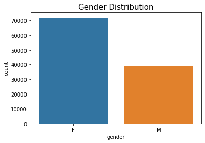

```python
# let's use count plot to check the gender distribution

plt.figure(figsize=(6,4))
sns.countplot(df['gender'])
plt.title('Gender Distribution', fontsize=15)
plt.show();
```

```python
# let's get the value count of each gender variable in a data frame

pd.DataFrame(df['gender'].value_counts())
```

|  | gender |
| --- | --- |
| F | 71839 |
| M | 38687 |

```python
# let's get the percentage of each gender value count

pd.DataFrame(df['gender'].value_counts(normalize=True)*100)
```

|  | gender |
| --- | --- |
| F | 64.997376 |
| M | 35.002624 |

[output not shown]

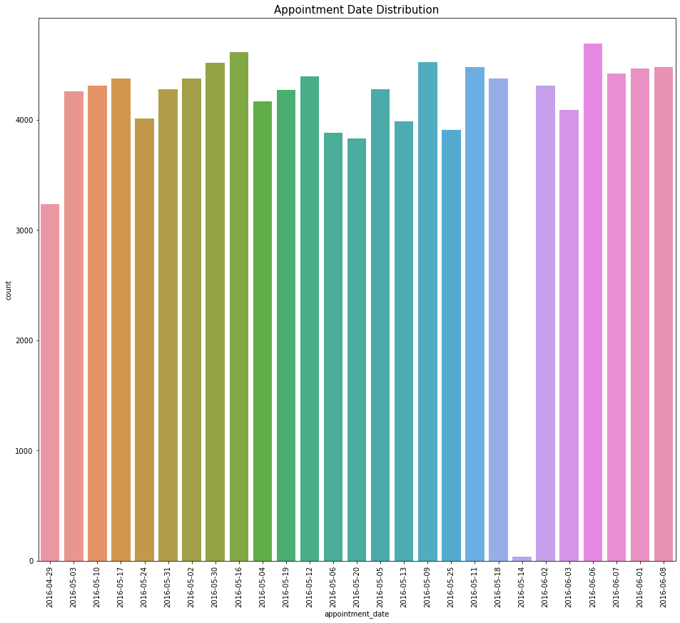

```python
# let's use count plot to check the appointment date distribution

plt.figure(figsize=(16,14))
sns.countplot(df['appointment_date'])
plt.title('Appointment Date Distribution', fontsize=15)
plt.xticks(rotation=90)
plt.show()
```

```python
# let's check the value count of each appointment_date variable in a data frame.

pd.DataFrame(df['appointment_date'].value_counts())
```

|  | appointment_date |
| --- | --- |
| 2016-06-06 | 4691 |
| 2016-05-16 | 4613 |
| 2016-05-09 | 4520 |
| 2016-05-30 | 4514 |
| 2016-06-08 | 4479 |
| 2016-05-11 | 4474 |
| 2016-06-01 | 4464 |
| 2016-06-07 | 4416 |
| 2016-05-12 | 4394 |
| 2016-05-02 | 4376 |
| 2016-05-18 | 4373 |
| 2016-05-17 | 4372 |
| 2016-06-02 | 4310 |
| 2016-05-10 | 4308 |
| 2016-05-31 | 4279 |
| 2016-05-05 | 4273 |
| 2016-05-19 | 4270 |
| 2016-05-03 | 4256 |
| 2016-05-04 | 4168 |
| 2016-06-03 | 4090 |
| 2016-05-24 | 4009 |
| 2016-05-13 | 3987 |
| 2016-05-25 | 3909 |
| 2016-05-06 | 3879 |
| 2016-05-20 | 3828 |
| 2016-04-29 | 3235 |
| 2016-05-14 | 39 |

```python
# let's get the percentage of each of the appointment_date value count

pd.DataFrame(df['appointment_date'].value_counts(normalize=True)*100)
```

|  | appointment_date |
| --- | --- |
| 2016-06-06 | 4.244250 |
| 2016-05-16 | 4.173679 |
| 2016-05-09 | 4.089535 |
| 2016-05-30 | 4.084107 |
| 2016-06-08 | 4.052440 |
| 2016-05-11 | 4.047916 |
| 2016-06-01 | 4.038869 |
| 2016-06-07 | 3.995440 |
| 2016-05-12 | 3.975535 |
| 2016-05-02 | 3.959249 |
| 2016-05-18 | 3.956535 |
| 2016-05-17 | 3.955630 |
| 2016-06-02 | 3.899535 |
| 2016-05-10 | 3.897725 |
| 2016-05-31 | 3.871487 |
| 2016-05-05 | 3.866059 |
| 2016-05-19 | 3.863344 |
| 2016-05-03 | 3.850678 |
| 2016-05-04 | 3.771058 |
| 2016-06-03 | 3.700487 |
| 2016-05-24 | 3.627201 |
| 2016-05-13 | 3.607296 |
| 2016-05-25 | 3.536724 |
| 2016-05-06 | 3.509581 |
| 2016-05-20 | 3.463438 |
| 2016-04-29 | 2.926913 |
| 2016-05-14 | 0.035286 |

```python
# let's check the unique appoinment days from the entire calendar

df['appointment_date'].nunique()
```

```
27
```

```python
# let's check the closest date of all appointments

df['appointment_date'].min()
```

```
datetime.date(2016, 4, 29)
```

```python
# let's get the farthest date of all appointments

df['appointment_date'].max()
```

```
datetime.date(2016, 6, 8)
```

There are 27 unique days of appointment for the patients beginning from 2016/04/29 to 2016/06/08.

More appointments were booked for 2016/06/06

[output not shown]

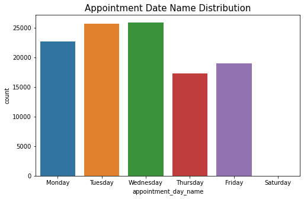

```python
# let's use count plot to check the appointment day name distribution

plt.figure(figsize=(8,5))
sns.countplot(df['appointment_day_name'],
              order=['Monday', 'Tuesday', 'Wednesday', 'Thursday', 'Friday', 'Saturday'])
plt.title('Appointment Date Name Distribution', fontsize=15)
plt.show();
```

```python
# let's check the value count of each appointment-day _name variable in a data frame

pd.DataFrame(df['appointment_day_name'].value_counts())
```

|  | appointment_day_name |
| --- | --- |
| Wednesday | 25867 |
| Tuesday | 25640 |
| Monday | 22714 |
| Friday | 19019 |
| Thursday | 17247 |
| Saturday | 39 |

```python
# let's get the percentage of each of the appointment_day _name value count

pd.DataFrame(df['appointment_day_name'].value_counts(normalize=True)*100)
```

|  | appointment_day_name |
| --- | --- |
| Wednesday | 23.403543 |
| Tuesday | 23.198162 |
| Monday | 20.550821 |
| Friday | 17.207716 |
| Thursday | 15.604473 |
| Saturday | 0.035286 |

More appointments were fixed on Wednesdays while Saturdays were the least

Also, appointments were fixed more during the weekdays than the weekends.

```python
# let's check the maximum number of days one would wait before appointment

df['number_of_waiting_days'].max()
```

```
Timedelta('178 days 13:19:01')
```

```python
# let's check the minimum number of days one would wait before appointment

df['number_of_waiting_days'].min()
```

```
Timedelta('-7 days +10:10:40')
```

[output not shown]

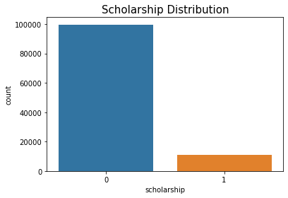

```python
# let's use the count plot to check the scholarship distribution

plt.figure(figsize=(6,4))
sns.countplot(df['scholarship'])
plt.title('Scholarship Distribution', fontsize=15)
plt.show()
```

```python
# let's check the value count of scholarship variable in a data frame

pd.DataFrame(df['scholarship'].value_counts())
```

|  | scholarship |
| --- | --- |
| 0 | 99665 |
| 1 | 10861 |

```python
# let's get the percentage of scholarship value count

pd.DataFrame(df['scholarship'].value_counts(normalize=True)*100)
```

|  | scholarship |
| --- | --- |
| 0 | 90.173353 |
| 1 | 9.826647 |

90%(99665) of the patients were not enrolled for scholarship, while only 9.83%(10861) were enrolled for the scholarship.

[output not shown]

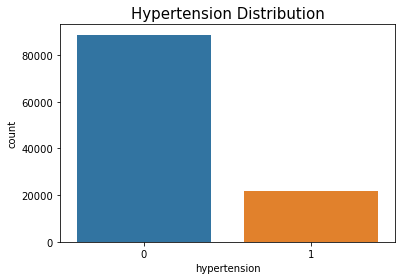

```python
# let's check the distributon of hypertension among the patients

plt.figure(figsize=(6,4))
sns.countplot(df['hypertension'])
plt.title('Hypertension Distribution', fontsize = 15)
plt.show()
```

```python
# let's check the value count of hypertension variable in a data frame

pd.DataFrame(df['hypertension'].value_counts())
```

|  | hypertension |
| --- | --- |
| 0 | 88725 |
| 1 | 21801 |

```python
# let's get the percentage of scholarship value count

pd.DataFrame(df['hypertension'].value_counts(normalize=True)*100)
```

|  | hypertension |
| --- | --- |
| 0 | 80.275229 |
| 1 | 19.724771 |

19.72%(21801) were sick with hypertension while 80%(88725) were not down with hypertension

[output not shown]

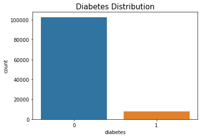

```python
# let's check the diabetes distribution among the patients

plt.figure(figsize =(6,4))
sns.countplot(df['diabetes'])
plt.title('Diabetes Distribution', fontsize=15)
plt.show()
```

```python
# let's check the value count of diabetes variable in a data frame

pd.DataFrame(df['diabetes'].value_counts())
```

|  | diabetes |
| --- | --- |
| 0 | 102583 |
| 1 | 7943 |

```python
# let's get the percentage of diabetes value count

pd.DataFrame(df['diabetes'].value_counts(normalize=True)*100)
```

|  | diabetes |
| --- | --- |
| 0 | 92.813456 |
| 1 | 7.186544 |

only 7.19%(7943) of the patients had diabetes while 92.8%(102583) did not suffer from diabetes.

[output not shown]

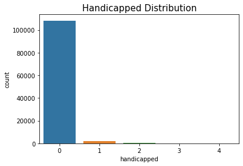

```python
# let's check the distributon of handicapped among the patients

plt.figure(figsize =(6,4))
sns.countplot(df['handicapped'])
plt.title('Handicapped Distribution', fontsize=15)
plt.show()
```

```python
# let's check the value count of handicapped variable in a data frame

pd.DataFrame(df['handicapped'].value_counts())
```

|  | handicapped |
| --- | --- |
| 0 | 108285 |
| 1 | 2042 |
| 2 | 183 |
| 3 | 13 |
| 4 | 3 |

```python
# let's get the percentage of handicapped value count

pd.DataFrame(df['handicapped'].value_counts(normalize=True)*100)
```

|  | handicapped |
| --- | --- |
| 0 | 97.972423 |
| 1 | 1.847529 |
| 2 | 0.165572 |
| 3 | 0.011762 |
| 4 | 0.002714 |

only 1.85%(2042) of the patients population were handicapped while 97.97%(108285) were not handicapped.

[output not shown]

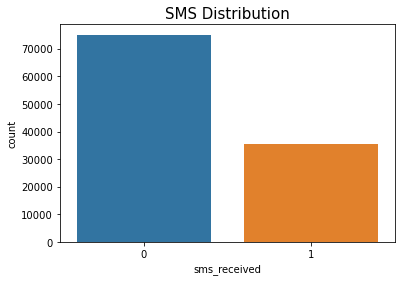

```python
# let's check the distributon of sms_received among the patients

plt.figure(figsize =(6,4))
sns.countplot(df['sms_received'])
plt.title('SMS Distribution', fontsize=15)
plt.show()
```

```python
# let's check the value count of sms received in a data frame

pd.DataFrame(df['sms_received'].value_counts())
```

|  | sms_received |
| --- | --- |
| 0 | 75044 |
| 1 | 35482 |

```python
# let's get the percentage of handicapped value count

pd.DataFrame(df['sms_received'].value_counts(normalize=True)*100)
```

|  | sms_received |
| --- | --- |
| 0 | 67.897146 |
| 1 | 32.102854 |

67.90%(75044) did not receive sms while 32.10%(35482) received sms.

[output not shown]

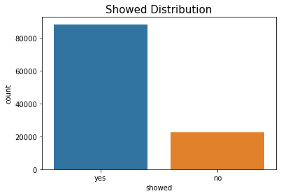

```python
# let's check the distributon of showed variable among the patients

plt.figure(figsize =(6,4))
sns.countplot(df['showed'])
plt.title('Showed Distribution', fontsize=15)
plt.show()
```

```python
# let's check the value count of showed variable in a data frame

pd.DataFrame(df['showed'].value_counts())
```

|  | showed |
| --- | --- |
| yes | 88207 |
| no | 22319 |

```python
# let's get the percentage of handicapped value count

pd.DataFrame(df['showed'].value_counts(normalize=True)*100)
```

|  | showed |
| --- | --- |
| yes | 79.806561 |
| no | 20.193439 |

```python
# let's create a function that we can use to plot a box plot for just the age variable

def unibox(df, var_name):
    """
    This function takes in a numerical variable and returns a boxplot of its distribution
    """
    sns.boxplot(data=df, x=var_name)
```

```python
df.age.describe()
```

```
count    110526.000000
mean         37.089219
std          23.110026
min           0.000000
25%          18.000000
50%          37.000000
75%          55.000000
max         115.000000
Name: age, dtype: float64
```

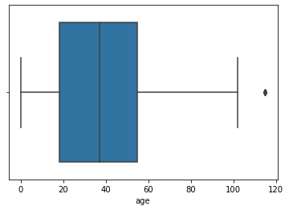

```python
# let's check the age distribution using the boxplots

unibox(df, 'age')
```

This shows that about 75% pf the population were between 0 to 55 years of age, the mean age was 37 years, while the maximum afe was 115, which seems to be an outlier.

## 2D or Bivariate Analysis

We will use countplots to carry out our bivariate analysis in other to check how the **showed variable which is the dependent variable** correlates with some of the **independent variable.**

```python
df.columns
```

```
Index(['gender', 'scheduledday', 'appointmentday', 'age', 'neighbourhood',
       'scholarship', 'hypertension', 'diabetes', 'alcoholism', 'handicapped',
       'sms_received', 'showed', 'number_of_waiting_days', 'appointment_date',
       'scheduled_date', 'appointment_day_name'],
      dtype='object')
```

### Does receiving SMS determine wether the patients show up or not?

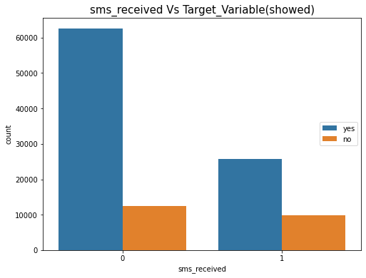

```python
# let's compare the sms_receive and showed variables and see how recieving sms
# contributed to the patients showing up or not.

plt.figure(figsize=(8,6))
sns.countplot(x='sms_received', hue='showed', data=df)
plt.title('sms_received Vs Target_Variable(showed)', fontsize=15)
plt.legend(loc='right')
plt.show()
```

```python
# let's use groupby to compare sms received and showed value counts

pd.DataFrame(df.groupby('sms_received')['showed'].value_counts())
```

| sms_received | showed | showed |
| --- | --- | --- |
| 0 | yes | 62509 |
|  | no | 12535 |
| 1 | yes | 25698 |
|  | no | 9784 |

```python
# let's get the percentage

pd.DataFrame(df.groupby('sms_received')['showed'].value_counts(normalize=True)*100)
```

| sms_received | showed | showed |
| --- | --- | --- |
| 0 | yes | 83.296466 |
|  | no | 16.703534 |
| 1 | yes | 72.425455 |
|  | no | 27.574545 |

A higher percentage of them did not received sms.

Among the people that received sms, 72%(25698) showed up while 27.57%(9784) did not show up.

### Does gender determine wether the patients show up or not?

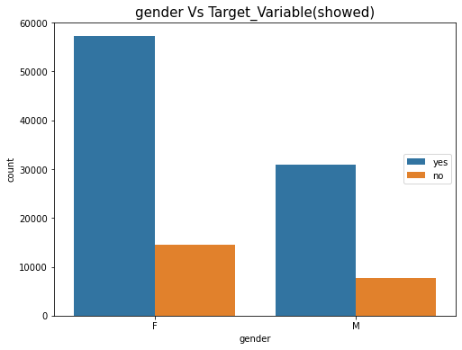

```python
# let's compare the gender and showed variables and see how being a female or male determine
# wether the patients show up or not.

plt.figure(figsize=(8,6))
sns.countplot(x='gender', hue='showed', data=df)
plt.title('gender Vs Target_Variable(showed)', fontsize=15)
plt.legend(loc='right')
plt.show()
```

```python
# let's use groupby to compare gender and showed value counts

pd.DataFrame(df.groupby('gender')['showed'].value_counts())
```

| gender | showed | showed |
| --- | --- | --- |
| F | yes | 57245 |
|  | no | 14594 |
| M | yes | 30962 |
|  | no | 7725 |

```python
# let's get the percentage

pd.DataFrame(df.groupby('gender')['showed'].value_counts(normalize=True)*100)
```

| gender | showed | showed |
| --- | --- | --- |
| F | yes | 79.685129 |
|  | no | 20.314871 |
| M | yes | 80.032052 |
|  | no | 19.967948 |

Both males and females had almost the same percentage of not showing up for their appointments with 19.96%(7725) for males and 20.31%(14594) for females.

In same way, both have the same percentage of showing up with 80%(30962) for males and 79.67%(57245) for females.

### Does closer appointment dates contributes to patients showing up or not?

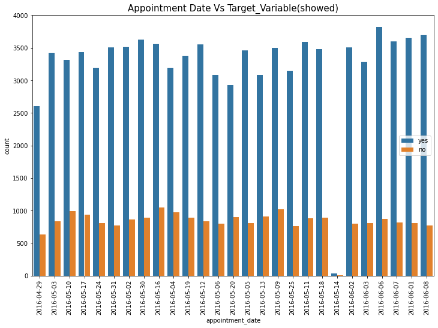

```python
# let's compare closer appointment dates to farther appointment dates

plt.figure(figsize=(12,8))
sns.countplot(x='appointment_date', hue='showed', data=df)
plt.title('Appointment Date Vs Target_Variable(showed)', fontsize=15)
plt.legend(loc='right')
plt.xticks(rotation=90)
plt.show()
```

```python
# let's use groupby to compare appointment_dates and showed value counts

pd.DataFrame(df.groupby('appointment_date')['showed'].value_counts())
```

| appointment_date | showed | showed |
| --- | --- | --- |
| 2016-04-29 | yes | 2602 |
|  | no | 633 |
| 2016-05-02 | yes | 3515 |
|  | no | 861 |
| 2016-05-03 | yes | 3425 |
|  | no | 831 |
| 2016-05-04 | yes | 3195 |
|  | no | 973 |
| 2016-05-05 | yes | 3466 |
|  | no | 807 |
| 2016-05-06 | yes | 3084 |
|  | no | 795 |
| 2016-05-09 | yes | 3501 |
|  | no | 1019 |
| 2016-05-10 | yes | 3316 |
|  | no | 992 |
| 2016-05-11 | yes | 3589 |
|  | no | 885 |
| 2016-05-12 | yes | 3557 |
|  | no | 837 |
| 2016-05-13 | yes | 3082 |
|  | no | 905 |
| 2016-05-14 | yes | 30 |
|  | no | 9 |
| 2016-05-16 | yes | 3564 |
|  | no | 1049 |
| 2016-05-17 | yes | 3437 |
|  | no | 935 |
| 2016-05-18 | yes | 3483 |
|  | no | 890 |
| 2016-05-19 | yes | 3378 |
|  | no | 892 |
| 2016-05-20 | yes | 2929 |
|  | no | 899 |
| 2016-05-24 | yes | 3198 |
|  | no | 811 |
| 2016-05-25 | yes | 3150 |
|  | no | 759 |
| 2016-05-30 | yes | 3626 |
|  | no | 888 |
| 2016-05-31 | yes | 3512 |
|  | no | 767 |
| 2016-06-01 | yes | 3652 |
|  | no | 812 |
| 2016-06-02 | yes | 3508 |
|  | no | 802 |
| 2016-06-03 | yes | 3285 |
|  | no | 805 |
| 2016-06-06 | yes | 3818 |
|  | no | 873 |
| 2016-06-07 | yes | 3600 |
|  | no | 816 |
| 2016-06-08 | yes | 3705 |
|  | no | 774 |

```python
# let's get the percentage

pd.DataFrame(df.groupby('appointment_date')['showed'].value_counts(normalize=True)*100)
```

| appointment_date | showed | showed |
| --- | --- | --- |
| 2016-04-29 | yes | 80.432767 |
|  | no | 19.567233 |
| 2016-05-02 | yes | 80.324497 |
|  | no | 19.675503 |
| 2016-05-03 | yes | 80.474624 |
|  | no | 19.525376 |
| 2016-05-04 | yes | 76.655470 |
|  | no | 23.344530 |
| 2016-05-05 | yes | 81.113971 |
|  | no | 18.886029 |
| 2016-05-06 | yes | 79.505027 |
|  | no | 20.494973 |
| 2016-05-09 | yes | 77.455752 |
|  | no | 22.544248 |
| 2016-05-10 | yes | 76.973073 |
|  | no | 23.026927 |
| 2016-05-11 | yes | 80.219043 |
|  | no | 19.780957 |
| 2016-05-12 | yes | 80.951297 |
|  | no | 19.048703 |
| 2016-05-13 | yes | 77.301229 |
|  | no | 22.698771 |
| 2016-05-14 | yes | 76.923077 |
|  | no | 23.076923 |
| 2016-05-16 | yes | 77.259918 |
|  | no | 22.740082 |
| 2016-05-17 | yes | 78.613907 |
|  | no | 21.386093 |
| 2016-05-18 | yes | 79.647839 |
|  | no | 20.352161 |
| 2016-05-19 | yes | 79.110070 |
|  | no | 20.889930 |
| 2016-05-20 | yes | 76.515152 |
|  | no | 23.484848 |
| 2016-05-24 | yes | 79.770516 |
|  | no | 20.229484 |
| 2016-05-25 | yes | 80.583269 |
|  | no | 19.416731 |
| 2016-05-30 | yes | 80.327869 |
|  | no | 19.672131 |
| 2016-05-31 | yes | 82.075251 |
|  | no | 17.924749 |
| 2016-06-01 | yes | 81.810036 |
|  | no | 18.189964 |
| 2016-06-02 | yes | 81.392111 |
|  | no | 18.607889 |
| 2016-06-03 | yes | 80.317848 |
|  | no | 19.682152 |
| 2016-06-06 | yes | 81.389896 |
|  | no | 18.610104 |
| 2016-06-07 | yes | 81.521739 |
|  | no | 18.478261 |
| 2016-06-08 | yes | 82.719357 |
|  | no | 17.280643 |

### Does having appointments during the weekdays or having appointments during the weekend contribute to patients showing up or not?

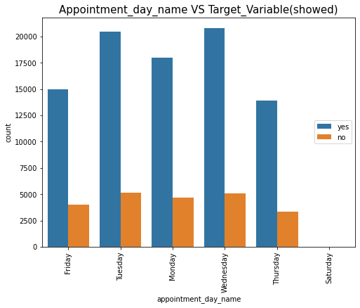

```python
# let's compare appointments that fall into the weekdays to appointments that fall into the weekends

plt.figure(figsize=(8,6))
sns.countplot(x='appointment_day_name', hue='showed', data=df)
plt.legend(loc='right')
plt.title('Appointment_day_name VS Target_Variable(showed)', fontsize = 15)
plt.xticks(rotation=90)
plt.show()
```

```python
# let's use groupby to compare appointment_day_name and showed value counts

pd.DataFrame(df.groupby('appointment_day_name')['showed'].value_counts())
```

| appointment_day_name | showed | showed |
| --- | --- | --- |
| Friday | yes | 14982 |
|  | no | 4037 |
| Monday | yes | 18024 |
|  | no | 4690 |
| Saturday | yes | 30 |
|  | no | 9 |
| Thursday | yes | 13909 |
|  | no | 3338 |
| Tuesday | yes | 20488 |
|  | no | 5152 |
| Wednesday | yes | 20774 |
|  | no | 5093 |

```python
# let's get the percentage

pd.DataFrame(df.groupby('appointment_day_name')['showed'].value_counts(normalize=True)*100)
```

| appointment_day_name | showed | showed |
| --- | --- | --- |
| Friday | yes | 78.773858 |
|  | no | 21.226142 |
| Monday | yes | 79.351942 |
|  | no | 20.648058 |
| Saturday | yes | 76.923077 |
|  | no | 23.076923 |
| Thursday | yes | 80.645909 |
|  | no | 19.354091 |
| Tuesday | yes | 79.906396 |
|  | no | 20.093604 |
| Wednesday | yes | 80.310821 |
|  | no | 19.689179 |

A higher percentage(80.65%) of patients showed up for their appointment on Thursdays while a lower percentage (76.9%) showed up on Saturdays.

### Does having a scholarship (a social welfare program by the government of Brazil) contributes to patients showing up or not?

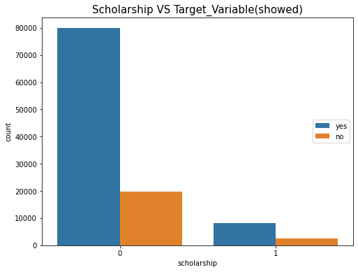

```python
# let's compare how patients with scholarship showed up to patients without scholarship

plt.figure(figsize=(8,6))
sns.countplot(x='scholarship', hue='showed', data=df)
plt.legend(loc='right')
plt.title('Scholarship VS Target_Variable(showed)', fontsize = 15)
plt.show()
```

```python
# let's use groupby to compare scholarship and showed value counts

pd.DataFrame(df.groupby('scholarship')['showed'].value_counts())
```

| scholarship | showed | showed |
| --- | --- | --- |
| 0 | yes | 79924 |
|  | no | 19741 |
| 1 | yes | 8283 |
|  | no | 2578 |

```python
# let's get the percentage

pd.DataFrame(df.groupby('scholarship')['showed'].value_counts(normalize=True)*100)
```

| scholarship | showed | showed |
| --- | --- | --- |
| 0 | yes | 80.192645 |
|  | no | 19.807355 |
| 1 | yes | 76.263696 |
|  | no | 23.736304 |

A much higher percentage of patients with scholarship (23.74%) did not show up for their appointments when compared with those without any scholarship (19.81%).

### Does a patient suffering from Diabetes contributes to the patient not showing up or not?

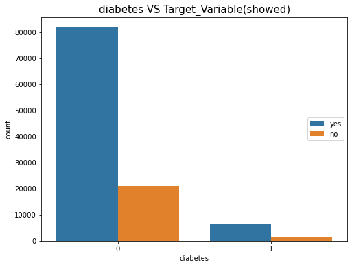

```python
# let's compare how patients who suffered from diabetes showed up to the patients who are not suffering from diabetes

plt.figure(figsize=(8,6))
sns.countplot(x='diabetes', hue='showed', data=df)
plt.legend(loc='right')
plt.title('diabetes VS Target_Variable(showed)', fontsize = 15)
plt.show()
```

```python
# let's use groupby to compare diabetes and showed value counts

pd.DataFrame(df.groupby('diabetes')['showed'].value_counts())
```

| diabetes | showed | showed |
| --- | --- | --- |
| 0 | yes | 81694 |
|  | no | 20889 |
| 1 | yes | 6513 |
|  | no | 1430 |

```python
# let's get the percentage

pd.DataFrame(df.groupby('diabetes')['showed'].value_counts(normalize=True)*100)
```

| diabetes | showed | showed |
| --- | --- | --- |
| 0 | yes | 79.636977 |
|  | no | 20.363023 |
| 1 | yes | 81.996727 |
|  | no | 18.003273 |

## Conclusion

- Receiving an sms does not contribute to the willingness to show up for their appointments, as from our analysis, the people that did not receive an sms even showed up more.
- Being a female or male does not influence their showing up for their appointments as from our analysis, both gender have almost the same percentage of showing up for their appointments.
- Patients who have a farther appointment dates were more likely to show up than patients with closer appointment dates.
- Patients whose appointment days fall in during the weekdays were more likely to show up than patients whose appointment days fall in during the weekends.
- Receiving a scholarship does not have an effect on the patients showing up as those without the scholarship showed up more.
- Patients who were suffering diabetes were more likely to show up than patients who were not suffering from diabetes.

## Limitations

- The conlusions above are based on my understanding of the dataset, so they should be taken as tentative.
- Even though there are no missing features and duplicate values in our data, statistical tests (t-test, anova) might still be required for final conclusion.